# Exploratory Data Analysis Report

2020-09-04

## Exploratory Data analysis (EDA)

Analyzing the data sets to summarize their main characteristics of variables, often with visual graphs, without using a statistical model.

### 1. Overview of the data

Understanding the dimensions of the dataset, variable names, overall missing summary and data types of each variables

```r
# Overiview of the data
ExpData(data=data,type=1)
# Structure of the data
ExpData(data=data,type=2)
```

**Overview of the data**

| Descriptions | Value |
| --- | --- |
| Sample size (nrow) | 32191 |
| No. of variables (ncol) | 47 |
| No. of numeric/interger variables | 33 |
| No. of factor variables | 12 |
| No. of text variables | 1 |
| No. of logical variables | 0 |
| No. of identifier variables | 2 |
| No. of date variables | 1 |
| No. of zero variance variables (uniform) | 1 |
| %. of variables having complete cases | 91.49% (43) |

[output cut: 3 more lines]

**Structure of the data**

| Index | Variable_Name | Variable_Type | Per_of_Missing | No_of_distinct_values |
| --- | --- | --- | --- | --- |
| 1 | module_id | factor | 0.00000 | 2 |
| 2 | ac_no | numeric | 0.00000 | 32191 |
| 3 | ac_title | factor | 0.00000 | 30531 |
| 4 | sme_sector | numeric | 0.08428 | 3 |
| 5 | sector_name | factor | 0.08428 | 3 |
| 6 | sme_category | factor | 0.00000 | 3 |
| 7 | scheme_cd | factor | 0.00000 | 68 |
| 8 | bsr_activity_cd | numeric | 0.00000 | 277 |
| 9 | industry_name | factor | 0.00000 | 264 |
| 10 | bsr_org_cd | numeric | 0.01314 | 26 |

[output cut: 37 more lines]

### 2. Summary of numerical variables

Summary of all numerical variables

Summary statistics when dependent variable is categorical **loan_default**. Summary statistics will be splitted into category level

```r
ExpNumStat(data,by="GA",gp=Target,Qnt=seq(0,1,0.1),MesofShape=2,Outlier=TRUE,round=2)
```

| Vname | Group | TN | nNeg | nZero | nPos | NegInf | PosInf | NA_Value | Per_of_Missing | sum | min | max | mean | median | SD | CV | IQR | Skewness | Kurtosis | 0% | 10% | 20% | 30% | 40% | 50% | 60% | 70% | 80% | 90% | … |
| --- | --- | --- | --- | --- | --- | --- | --- | --- | --- | --- | --- | --- | --- | --- | --- | --- | --- | --- | --- | --- | --- | --- | --- | --- | --- | --- | --- | --- | --- | --- |
| ac_no | loan_default:All | 32191 | 0 | 0 | 32191 | 0 | 0 | 0 | 0.00 | 5.929967e+18 | 1089037101.00 | 3.807037e+14 | 1.842120e+14 | 1.741037e+14 | 1.123063e+14 | 0.61 | 1.892146e+14 | 0.08 | -1.24 | 1089037101.00 | 3.070313e+13 | 6.780371e+13 | 1.052037e+14 | 1.395037e+14 | 1.741037e+14 | 2.287037e+14 | 2.629037e+14 | 2.994037e+14 | 3.445037e+14 | … |
| ac_no | loan_default:0 | 25151 | 0 | 0 | 25151 | 0 | 0 | 0 | 0.00 | 4.628558e+18 | 1089037102.00 | 3.807037e+14 | 1.840308e+14 | 1.738330e+14 | 1.123025e+14 | 0.61 | 1.895854e+14 | 0.08 | -1.24 | 1089037102.00 | 3.070313e+13 | 6.780371e+13 | 1.051037e+14 | 1.395031e+14 | 1.738330e+14 | 2.281037e+14 | 2.629031e+14 | 3.001037e+14 | 3.443037e+14 | … |
| ac_no | loan_default:1 | 7040 | 0 | 0 | 7040 | 0 | 0 | 0 | 0.00 | 1.301409e+18 | 1089037101.00 | 3.802330e+14 | 1.848593e+14 | 1.750037e+14 | 1.123255e+14 | 0.61 | 1.892000e+14 | 0.07 | -1.23 | 1089037101.00 | 3.160371e+13 | 6.790371e+13 | 1.063037e+14 | 1.411213e+14 | 1.750037e+14 | 2.298037e+14 | 2.633036e+14 | 2.988037e+14 | 3.464237e+14 | … |
| asset_cost | loan_default:All | 32191 | 0 | 0 | 32191 | 0 | 0 | 0 | 0.00 | 2.295700e+10 | 370000.00 | 1.628992e+07 | 7.131498e+05 | 6.671500e+05 | 1.917335e+05 | 0.27 | 1.035550e+05 | 18.62 | 1359.99 | 370000.00 | 5.882500e+05 | 6.176500e+05 | 6.354000e+05 | 6.515900e+05 | 6.671500e+05 | 6.843200e+05 | 7.107200e+05 | 7.632200e+05 | 9.236700e+05 | … |
| asset_cost | loan_default:0 | 25151 | 0 | 0 | 25151 | 0 | 0 | 0 | 0.00 | 1.794335e+10 | 370000.00 | 1.628992e+07 | 7.134250e+05 | 6.668000e+05 | 1.974094e+05 | 0.28 | 1.042100e+05 | 21.34 | 1546.85 | 370000.00 | 5.890000e+05 | 6.176000e+05 | 6.351900e+05 | 6.510600e+05 | 6.668000e+05 | 6.842600e+05 | 7.114100e+05 | 7.644900e+05 | 9.231500e+05 | … |
| asset_cost | loan_default:1 | 7040 | 0 | 0 | 7040 | 0 | 0 | 0 | 0.00 | 5.013653e+09 | 370000.00 | 2.811640e+06 | 7.121666e+05 | 6.682500e+05 | 1.699235e+05 | 0.24 | 1.016800e+05 | 2.76 | 12.78 | 370000.00 | 5.855760e+05 | 6.177780e+05 | 6.364570e+05 | 6.529820e+05 | 6.682500e+05 | 6.843800e+05 | 7.088100e+05 | 7.599200e+05 | 9.270540e+05 | … |
| bsr_activity_cd | loan_default:All | 32191 | 0 | 0 | 32191 | 0 | 0 | 0 | 0.00 | 1.730382e+09 | 1101.00 | 9.999900e+04 | 5.375360e+04 | 5.231900e+04 | 2.263727e+04 | 0.42 | 9.002000e+03 | 0.30 | -0.12 | 1101.00 | 1.920100e+04 | 3.520100e+04 | 5.190900e+04 | 5.231900e+04 | 5.231900e+04 | 5.231900e+04 | 5.231900e+04 | 6.593400e+04 | 9.300200e+04 | … |
| bsr_activity_cd | loan_default:0 | 25151 | 0 | 0 | 25151 | 0 | 0 | 0 | 0.00 | 1.351853e+09 | 1101.00 | 9.999900e+04 | 5.374949e+04 | 5.231900e+04 | 2.267091e+04 | 0.42 | 9.002000e+03 | 0.30 | -0.12 | 1101.00 | 1.910200e+04 | 3.510100e+04 | 5.190900e+04 | 5.231900e+04 | 5.231900e+04 | 5.231900e+04 | 5.231900e+04 | 6.593400e+04 | 9.300200e+04 | … |
| bsr_activity_cd | loan_default:1 | 7040 | 0 | 0 | 7040 | 0 | 0 | 0 | 0.00 | 3.785287e+08 | 1101.00 | 9.999900e+04 | 5.376828e+04 | 5.231900e+04 | 2.251827e+04 | 0.42 | 9.001000e+03 | 0.33 | -0.09 | 1101.00 | 2.010100e+04 | 3.590100e+04 | 5.190900e+04 | 5.231900e+04 | 5.231900e+04 | 5.231900e+04 | 5.231900e+04 | 6.593400e+04 | 9.300200e+04 | … |
| bsr_org_cd | loan_default:All | 32191 | 0 | 1 | 31767 | 0 | 0 | 423 | 1.31 | 1.358347e+06 | 0.00 | 8.100000e+01 | 4.276000e+01 | 4.100000e+01 | 4.260000e+00 | 0.10 | 1.000000e+00 | 2.24 | 7.54 | 0.00 | 4.100000e+01 | 4.100000e+01 | 4.100000e+01 | 4.100000e+01 | 4.100000e+01 | 4.100000e+01 | 4.200000e+01 | 4.200000e+01 | 5.100000e+01 | … |

[output cut: 59 more lines]

### 3. Distributions of Numerical variables

- Box plots for all numerical variables vs categorical dependent variable - Bivariate comparision only with categories
  - Quantile-quantile plot(Univariate)
  - Density plot (Univariate)
  - Box plot (Univariate and Bivariate)
  - Scatter plot (Bivariate)

#### Quantile-quantile plot for Numerical variables - Univariate

Quantile-quantile plot for all Numerical variables

```r
ExpOutQQ(data,nlim=4,fname=NULL,Page=c(2,2),sample=sn)
```

```
## $`0`
```

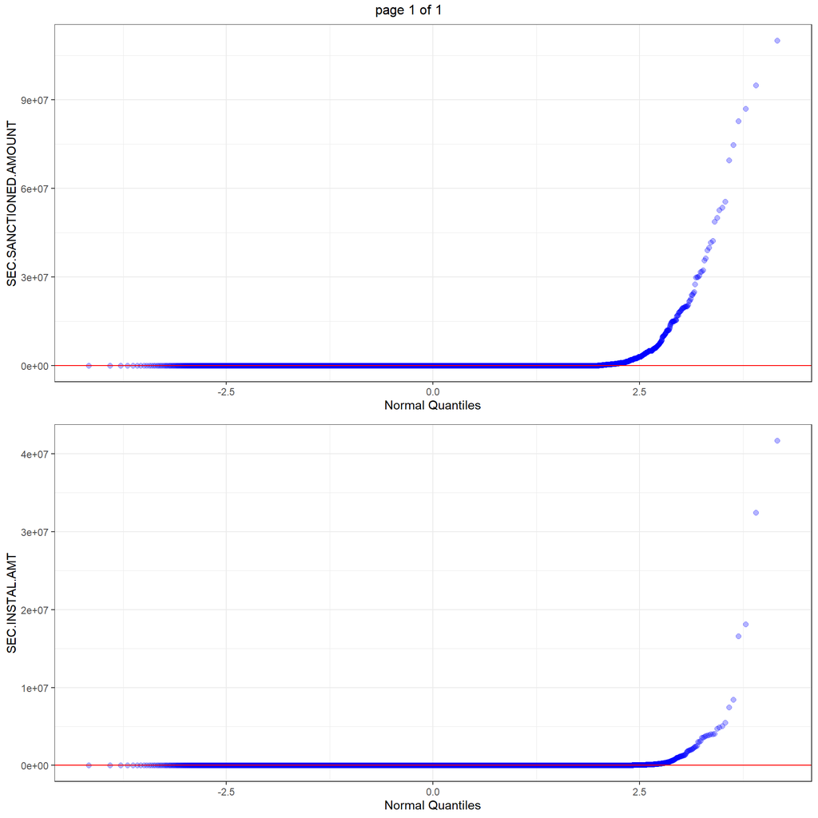

#### Density plots for Numerical variables - Univariate

Density plot for all Numerical variables

```
## $`0`
```

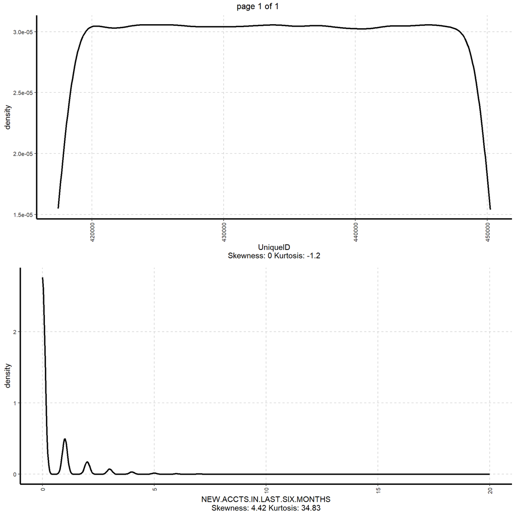

```r
ExpNumViz(data,target=NULL,type=1,Page=c(2,2),theme=theme,sample=sn)
```

#### Scatter plot for all numeric features - Bivariate analysis

```
## $`0`
```

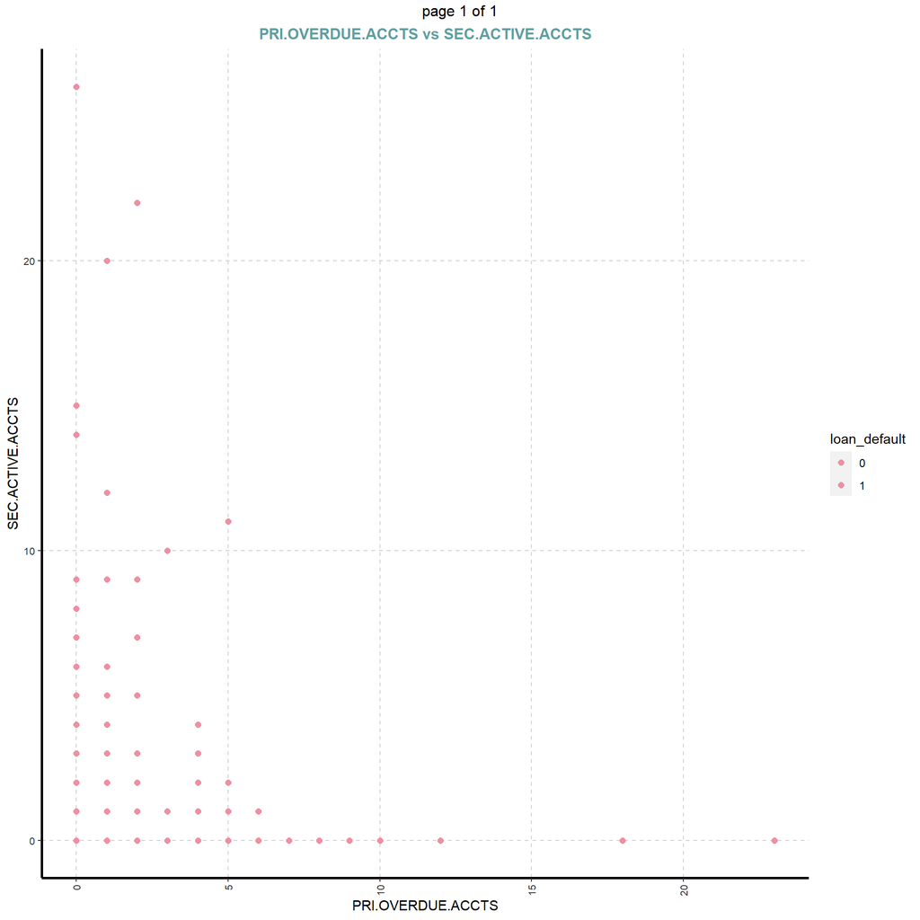

```r
ExpNumViz(data,target=Target,Page=c(2,1),theme=theme,sample=sn,scatter=TRUE)
```

#### Box plots for all numeric features vs categorical dependent variable - Bivariate comparision only with categories

Boxplot for all the numeric attributes by each category of **loan_default**

```
## $`0`
```

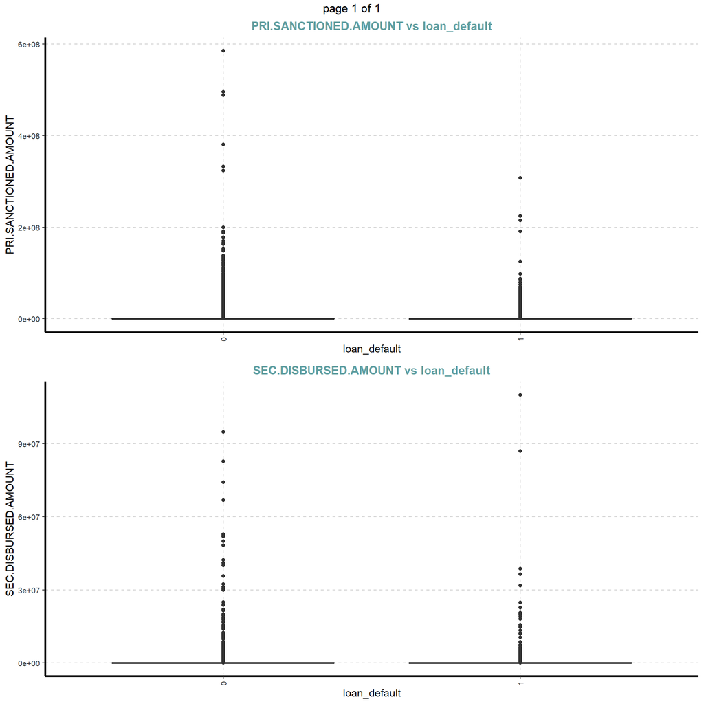

```r
ExpNumViz(data,target=Target,type=2,theme=theme,Page=c(2,2),sample=sn)
```

### 4. Summary of categorical variables

Summary of categorical variable

**Cross tabulation with target variable**

- Custom tables between all categorical independent variables and traget variable **loan_default**

```r
ExpCTable(data,Target=Target,margin=1,clim=10,nlim=5,round=2,bin=NULL,per=F)
```

| VARIABLE | CATEGORY | loan_default:0 | loan_default:1 | TOTAL |
| --- | --- | --- | --- | --- |
| module_id | adv | 21337 | 5935 | 27272 |
| module_id | cdcc | 3814 | 1105 | 4919 |
| module_id | TOTAL | 25151 | 7040 | 32191 |
| sector_name | Manufacturing | 5323 | 1489 | 6812 |
| sector_name | NA | 2119 | 594 | 2713 |
| sector_name | Services | 17709 | 4957 | 22666 |
| sector_name | TOTAL | 25151 | 7040 | 32191 |
| sme_category | MEDIU | 68 | 17 | 85 |
| sme_category | MICRO | 23243 | 6465 | 29708 |
| sme_category | SMALL | 1840 | 558 | 2398 |

[output cut: 30 more lines]

**Information Value**

```r
ExpCatStat(data,Target=Target,Label=label,result = "IV",clim=10,nlim=5,Pclass=Rc)
```

| Variable | Class | Out_1 | Out_0 | TOTAL | Per_1 | Per_0 | Odds | WOE | IV | Ref_1 | Ref_0 | Target |
| --- | --- | --- | --- | --- | --- | --- | --- | --- | --- | --- | --- | --- |
| module_id.1 | adv | 27272 | 27272 | 54544 | 0.85 | 0.85 | 1 | 0 | 0 | Yes | 0, 1 | loan_default |
| module_id.2 | cdcc | 4919 | 4919 | 9838 | 0.15 | 0.15 | 1 | 0 | 0 | Yes | 0, 1 | loan_default |
| sector_name.1 | Manufacturing | 6812 | 6812 | 13624 | 0.21 | 0.21 | 1 | 0 | 0 | Yes | 0, 1 | loan_default |
| sector_name.2 | Services | 22666 | 22666 | 45332 | 0.70 | 0.70 | 1 | 0 | 0 | Yes | 0, 1 | loan_default |
| sector_name.3 | NA | 2713 | 2713 | 5426 | 0.08 | 0.08 | 1 | 0 | 0 | Yes | 0, 1 | loan_default |
| sme_category.1 | MEDIU | 85 | 85 | 170 | 0.00 | 0.00 | 1 | NaN | NaN | Yes | 0, 1 | loan_default |
| sme_category.2 | MICRO | 29708 | 29708 | 59416 | 0.92 | 0.92 | 1 | 0 | 0 | Yes | 0, 1 | loan_default |
| sme_category.3 | SMALL | 2398 | 2398 | 4796 | 0.07 | 0.07 | 1 | 0 | 0 | Yes | 0, 1 | loan_default |
| Employment.Type.1 | Salaried | 14809 | 14809 | 29618 | 0.46 | 0.46 | 1 | 0 | 0 | Yes | 0, 1 | loan_default |
| Employment.Type.2 | Self employed | 16524 | 16524 | 33048 | 0.51 | 0.51 | 1 | 0 | 0 | Yes | 0, 1 | loan_default |

[output cut: 124 more lines]

**Statistical test**

```r
ExpCatStat(data,Target=Target,Label=label,result = "Stat",clim=10,nlim=5,Pclass=Rc)
```

| Variable | Target | Unique | Chi-squared | p-value | df | IV Value | Cramers V | Degree of Association | Predictive Power |
| --- | --- | --- | --- | --- | --- | --- | --- | --- | --- |
| module_id | loan_default | 2 | 1.160 | 0.281 | 1 | 0 | 0.01 | Very Weak | Not Predictive |
| sector_name | loan_default | 3 | 0.000 | 0.998 | 1 | 0 | 0.00 | Very Weak | Not Predictive |
| sme_category | loan_default | 3 | 3.126 | 0.210 | 2 | 0 | 0.01 | Very Weak | Not Predictive |
| Employment.Type | loan_default | 3 | 10.220 | 0.001 | 1 | 0 | 0.02 | Very Weak | Not Predictive |
| sme_sector | loan_default | 3 | 0.000 | 0.998 | 1 | 0 | 0.00 | Very Weak | Not Predictive |
| Aadhar_flag | loan_default | 2 | 49.678 | 0.000 | 1 | 0 | 0.04 | Very Weak | Not Predictive |
| PAN_flag | loan_default | 2 | 0.000 | 0.983 | 1 | 0 | 0.00 | Very Weak | Not Predictive |
| VoterID_flag | loan_default | 2 | 55.547 | 0.000 | 1 | 0 | 0.04 | Very Weak | Not Predictive |
| Driving_flag | loan_default | 2 | 0.771 | 0.380 | 1 | 0 | 0.00 | Very Weak | Not Predictive |
| Passport_flag | loan_default | 2 | 0.870 | 0.351 | 1 | 0 | 0.01 | Very Weak | Not Predictive |

[output cut: 25 more lines]

**Variable importance based on Information value**

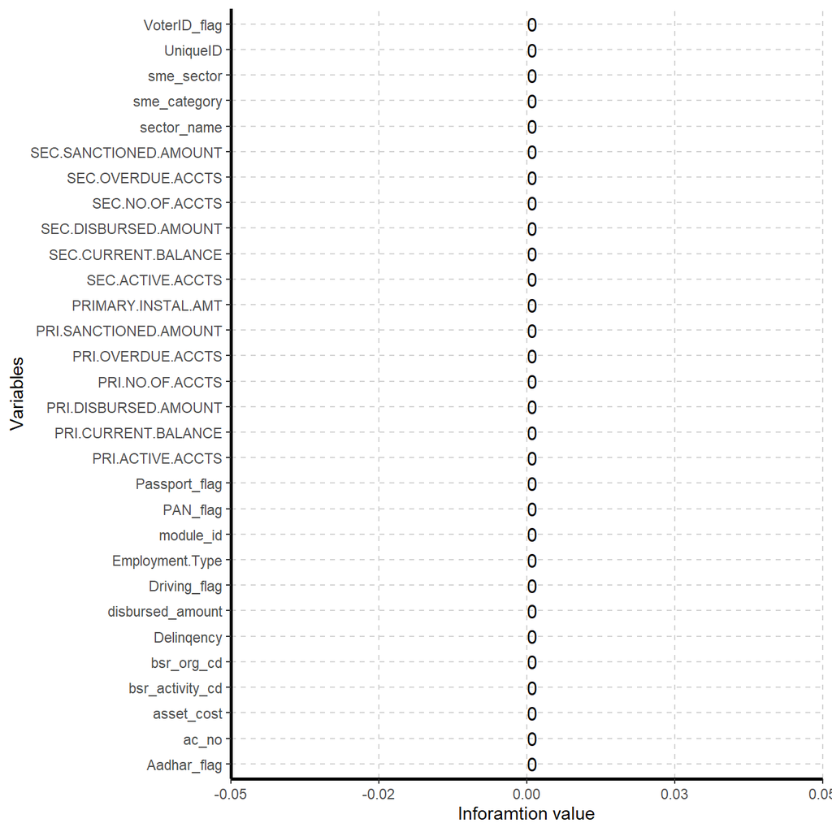

```r
varimp <- ExpCatStat(data,Target=Target,result = "Stat",clim=10,nlim=5,Pclass=Rc,bins=10,plot=TRUE,top=30,Round=2)
```

### 5. Distributions of categorical variables

Graphical representation of all categorical variables

- Bar plot (Univariate)
- Stacked Bar plot (Bivariate)

**Bar plots for all categorical variables**

- Bar plot with vertical or horizontal bars for all categorical variables

```
## $`0`
```

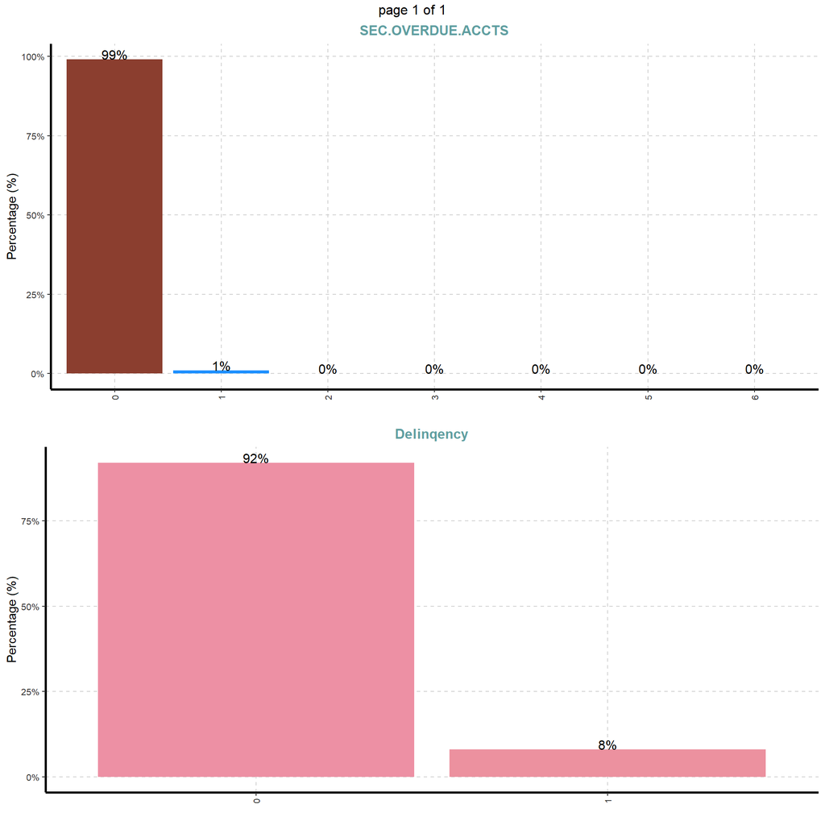

```r
ExpCatViz(data,target=NULL,fname=NULL,clim=10,margin=2,theme=theme,Page = c(2,1),sample=sc)
```

```
## $`0`
```

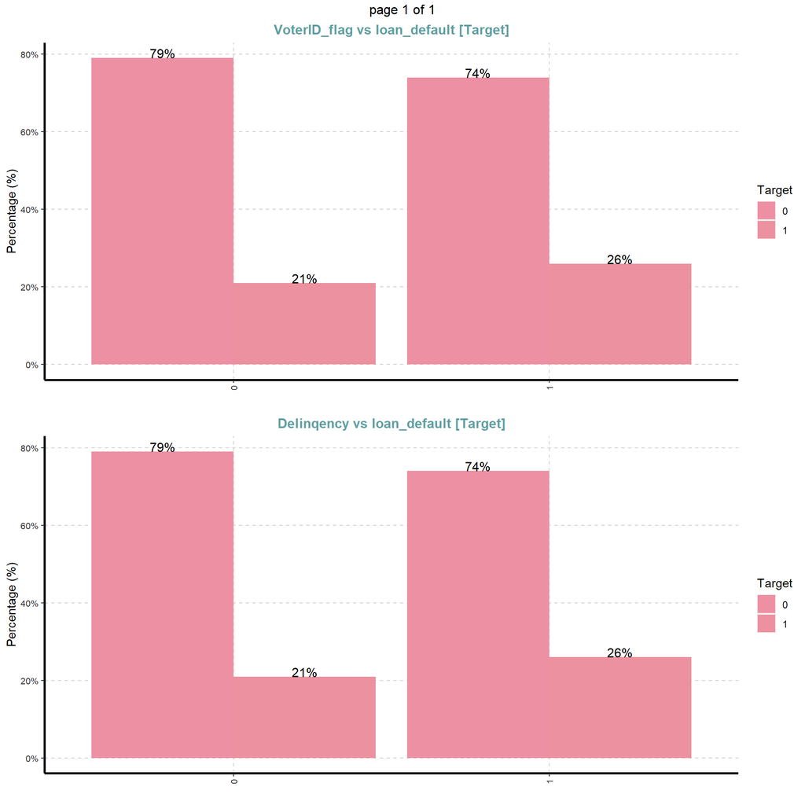

```r
ExpCatViz(data,target=Target,fname=NULL,clim=10,margin=2,theme=theme,Page = c(2,1),sample=sc)
```